# Metal Up Your R’s

Michael Laurila

2024-09-13

🔊 *Metal music has an average loudness of* -7 *on a scale from -60 to 0. Mind your volume settings.* 🔊

# Classifying music is hard (but metal is harder)

> *… the* musical boundaries of the genre have sprawled so far  
> that today the phrase heavy metal *is ridiculously vague.*

> – Kim Neely in Rolling Stone, October 4th 1990

To file the entirety of metal music under *heavy metal* would be even more ridiculous today. The evolution of music, paired with our unrelenting need to categorize, has granulated the genre space to a point where the mere presence of an electric guitar doesn’t cut it anymore. Even the phrase *death metal*, at the time of inception thought of as an extreme subgenre, is approaching ridiculous on the scale of vaguness. Several (sub-)subgenres with distinct sounds has emerged since the 90’s: do you prefer the complex rhythmic structures of [technical death metal](https://en.wikipedia.org/wiki/Technical_death_metal) or the high-pitched shrieks and harmonized guitars in [melodic death metal](https://en.wikipedia.org/wiki/Melodic_death_metal)? (The answer is **yes**.)

Putting aside distorted guitars and heavy riffs; fashion, attitude, and ideology also serves as defining characteristics of some genres. Notable examples beeing the coiffures of [glam metal](https://en.wikipedia.org/wiki/Glam_metal) and the Christian messages in [Christian metal](https://en.wikipedia.org/wiki/Christian_metal). Besides having one of the lowest proportions of explicit songs in its body of work, pulling a random song out of the Christian metal catalogue gives little promise as to the musical experience unless our holy grail is solely the absence of profanity. Neither does a banging hairdo generally speak volumes about the style of music that comes out of it. Since we will not be writing neural networks that detects hairspray levels nor do word analysis on lyrics in search of heathens, our focus will be aimed at the *sound* of music.

Explicit songs in selected genres.

| Genre | Explicit songs (%) |
| --- | --- |
| Black Metal | 11.2 |
| Christian Metal | 2.1 |
| Deathcore | 20.0 |

A common, and natural, metric for music classification is *tempo*. Metal is often considered a highly energetic and fast type of music; several genres has “fast tempo” explicitly mentioned as a defining characteristic, or implicitly in the term “[blast beat drumming](https://en.wikipedia.org/wiki/Blast_beat)”. Slower genres such as [Doom](https://en.wikipedia.org/wiki/Doom_metal) and [Stoner metal](https://en.wikipedia.org/wiki/Stoner_rock) break the stereotype and offers a home to the sluggish. Suppose that tempo acted as the sorting hat for metal, in which house of genres would it put the band [TOOL](https://sv.wikipedia.org/wiki/Tool)?

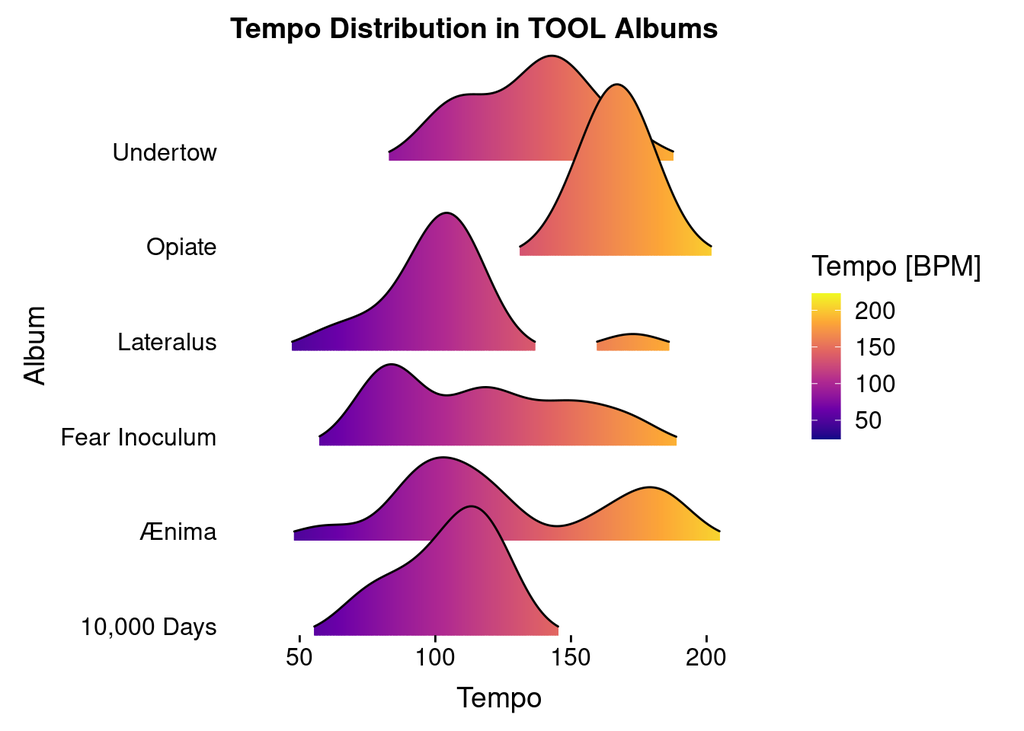

[interactive chart not shown]

*Intension* from *10,000 Days* with 95 BPM and *Lateralus* (the orange bump) from *Lateralus* with 173 BPM.

One could probably find a way to use the tempo information to make a definitive decision but it is not clear-cut which method should be used. Now add the other factors which go into describing the sound of music: key, mode, instruments etc. How can we ever hope to label any band as belonging to such and such a genre?

# Let someone else do the work

Between writing a thesis about musical genres and letting my mom list every growl over a distorted guitar as “Efter Döden-musik” (really, that’s what she calls it, bless her heart), [Wikipedia’s lists of bands under various metal subgenres](https://en.wikipedia.org/wiki/List_of_heavy_metal_bands) serves as a middle ground. Out of the 3486 artists found in 24 subgenre lists, 1146 (~ 33%) of them are found in *at least* two different genres (the norwegian band Vardøger is listed in 8 different genres)! If this is a product of the musical agility of the bands, their ability to compose music which spans over the genres, or a demonstration of the fuzzy lines which constitutes the genre boundaries, is a question for another day. We’re just happy that we got a list of genre classified bands, because bands make songs and songs is data.

# Put your numbers where your music is

Querying the [Spotify API](https://developer.spotify.com/documentation/web-api/reference/#/) about the 3486 bands found on Wikipedia yielded 36245 albums containing 302447 tracks combining to 2.5 years of metal music. Each track comes with a set of audio features including amongst others tempo, key, mode, and the high level metrics *danceability* and *energy*. While the energy in metal music typically is high, the averages between the least and most energetic genres is not insignificant. Doom Metal has an average energy level of 0.67, on the other side sits Deathcore with 0.91.

[interactive chart not shown]

*The Solace* by Doom metal band *My Dying Bride* with an energy of 0.205 and *So Far Too Long* by Deathcore band *All Shall Perish* with an energy of 0.949.

Calling yourself a dancer because of your ability to headbang and attending the occasional mosh pit is somewhat of a stretch. Metal music is seldom associated with dancing and this is reflected in every genre’s danceability average. Some bands blur the lines between metal and pop and does permit moves that could be considered dancing.

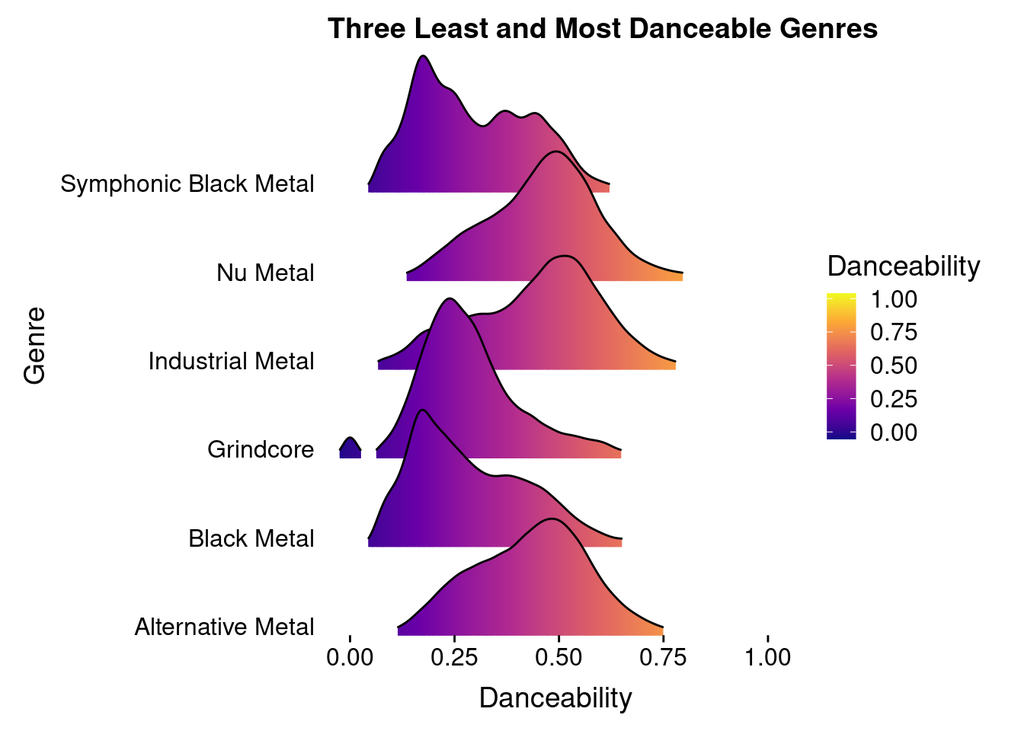

[interactive chart not shown]

*Perfection or Vanity* by Symphonic black metal band *Dimmu Borgir* with a danceability of 0.0687 and *Pimpin'* by Nu metal band *Hollywood Undead* with a danceability of 0.857.

A more direct notion of the sound of a song is which key and mode it is played in. By finding the proportion of songs in a certain key and mode for each genre we see a surprising variety between them.

Notible examples include the high number of songs in D-flat in Grindcore and the high proportion of songs in minor keys in Gothic metal.

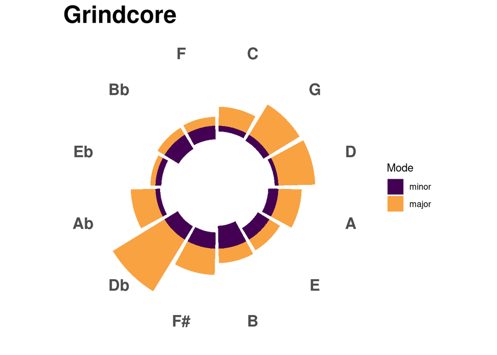

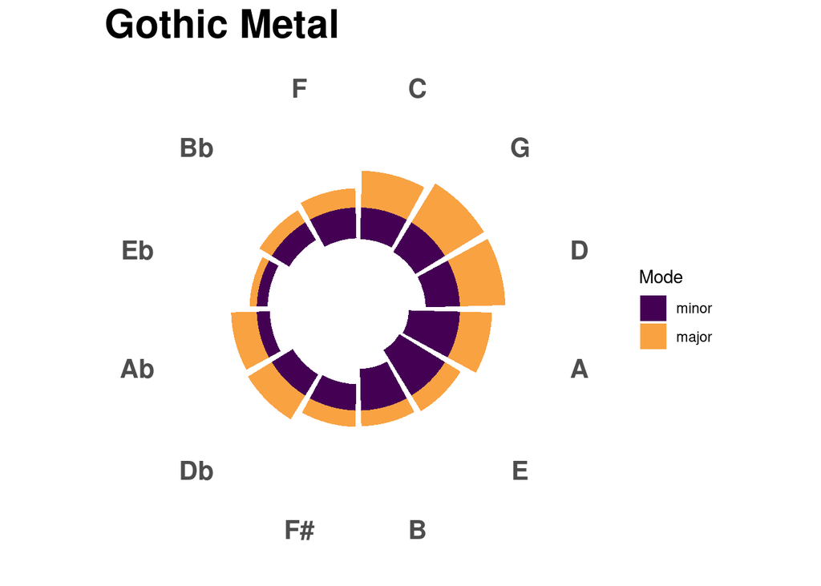

[interactive chart not shown]

*Wound 91* in D-flat by Grindcore band *Godflesh* and *You're So Vain* in A minor by Gothic metal band *Marilyn Manson*.

# Does it all sound the same?

Pulling songs based on the extremes of data shows that metal as a whole has a lot of breadth. When entering new genres it can often be difficult to navigate, most of the songs sounds the same. Using this data driven search for new music enables one to look at different aspects of a genre, choosing which artist or song to listen to next. This can be a tad tedious when browsing in the Spotify GUI since its “Related Artists” and “Fans Also Like” features lack the specificity that raw numbers provide. In using Spotify for over 10 years I have never experienced this level of control in my music browsing, this process can certainly be expanded to more genres, and functions written to tailor the needs of the listener.

[About the title](https://www.revolvermag.com/culture/metal-your-ass-how-metallicas-kill-em-all-got-its-iconic-art-and-title)  
[Kim Neely reviewing Anthrax’s album Persistence of Time, October 4th 1990](https://web.archive.org/web/20080108121842/http://www.rollingstone.com/artists/anthrax/albums/album/302316/review/5946559/persistence_of_time)